# Suavizacao e Decomposicao

```r
pacman::p_load(forecast,fpp2,magrittr)
```

Em series temporais temos o interesse em conseguir decompor a serie em componentes que sejam mais simples de serem modeladas, para isso temos duas formas de decompor uma serie

- **Aditiva:**

  $$X_t = T_t + S_t + E_t$$
- **Multiplicativa:**

  $$X_t = T_t \times S_t \times E_t$$

Sendo

- $T_t$: a componente de **tendência**
- $S_t$: a componente de **sazonalidade**
- $E_t$: um **ruído** (a parte não explicada, que espera-se ser puramente aleatória)

### Decomposicao Aditiva Clássica

Aqui temos a decomposicao aditiva feita diretamente pela funcao *decompose()* do R

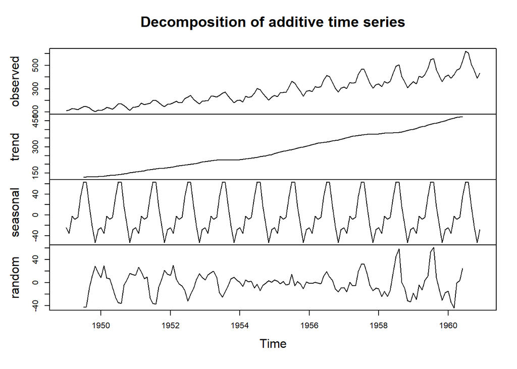

```r
X =  AirPassengers
dec = decompose(X, type="a")
plot(dec)
```

### Decomposicao Multiplicativa Clássica

Aqui repetimos o processo porem tratando de forma multiplicativa

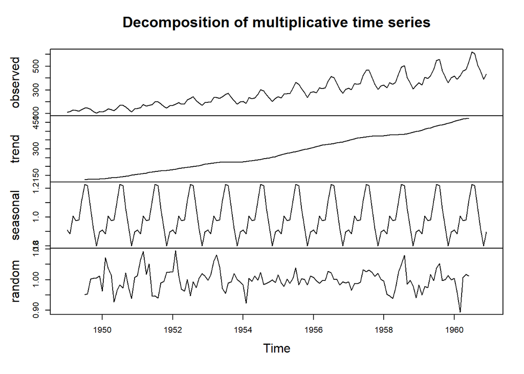

```r
dec = decompose(X, type="m")
plot(dec)
```

### Extraindo Tendendencia

Nessa etapa estamos interessados em entender como obter a componente de tendencia, para isso temos varios metodos um deles é utilizado pela funcao do R.

#### Funcao Linear

Aqui ajustamos uma regressao linear para obter a tendencia da serie

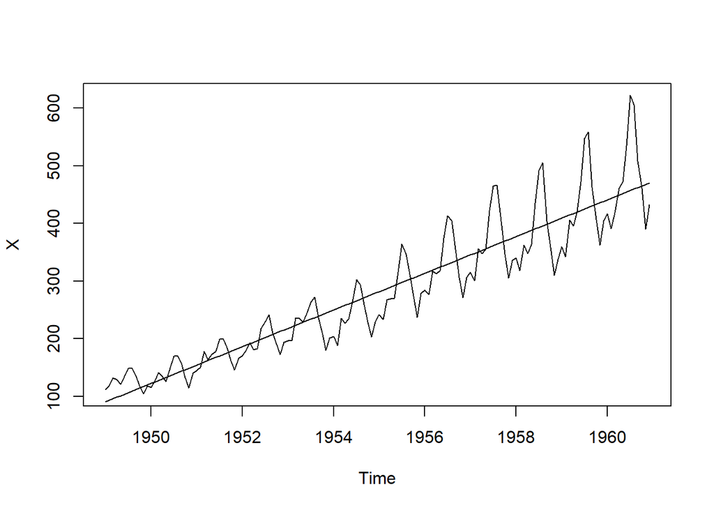

```r
tempo = time(X)
out = lm(X ~ tempo)
plot(X)
lines(x=tempo, y=out$fitted,
type='l')
```

#### Funcao Polinomial

Para casos em que a serie tenha uma tendencia “inconsistente” subindo e descendo podemos ajustar um polinomio

```r
X = Nile
tempo = as.numeric(time(X))
out = lm(X ~ poly(tempo,2))
out2 = lm(X ~ poly(tempo,6))
```

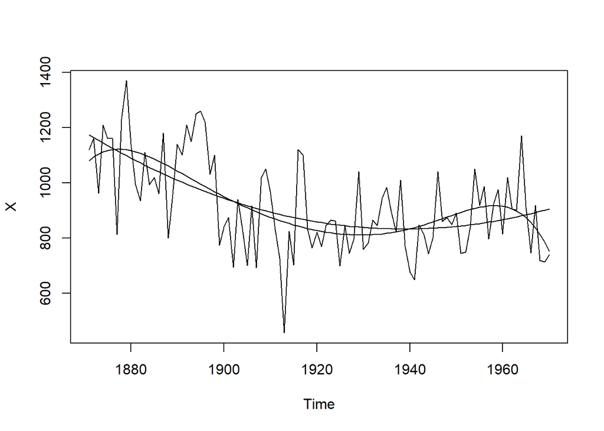

```r
plot(X)
lines(x=tempo, y=out$fitted,
type='l')
lines(x=tempo, y=out2$fitted,
type='l')
```

#### Suavizacao por Medias Moveis

Aqui chegamos no método mais utilizado, que é a media movel.

```r
X =  AirPassengers
SMA6 <- filter(X, rep(1/6,
6),sides=1)
SMA12 <- filter(X, rep(1/12,
12), sides=1)
```

No grafico abaixo podemos notar que quando usamos a media movel com 6 valores em uma serie com sazonalidade anual, ela é incapaz de extrair corretamente a tendencia, ainda resta sazonalidade.

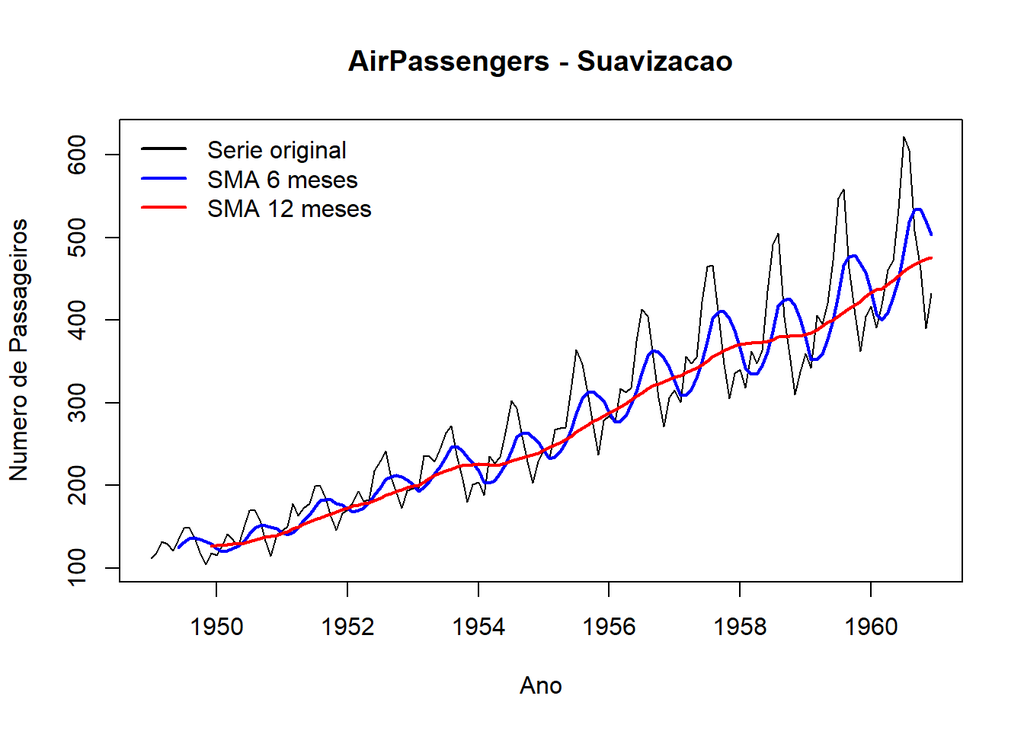

```r
# Gráfico
plot(X, main="AirPassengers - Suavizacao", ylab="Numero de Passageiros", xlab="Ano")

# Adiciona suavizações
lines(SMA6, col="blue", lwd=2)
lines(SMA12, col="red", lwd=2)

# Legenda
legend("topleft",
       legend=c("Serie original","SMA 6 meses","SMA 12 meses"),
       col=c("black","blue","red"),
       lty=1, lwd=2, bty="n")
```

### MM Simetrica X MM Passado

Temos duas formas de calcular uma MM, sendo ela usando valores passados ou simetrica (usando alguns valores futuros). A diferenca é que a serie usando valores passados vai ter um “atraso”.

```r
X <- AirPassengers
pass5 <- filter(X, rep(1/5, 5), sides=1)
sim5 <- filter(X, rep(1/5, 5), sides=2)
```

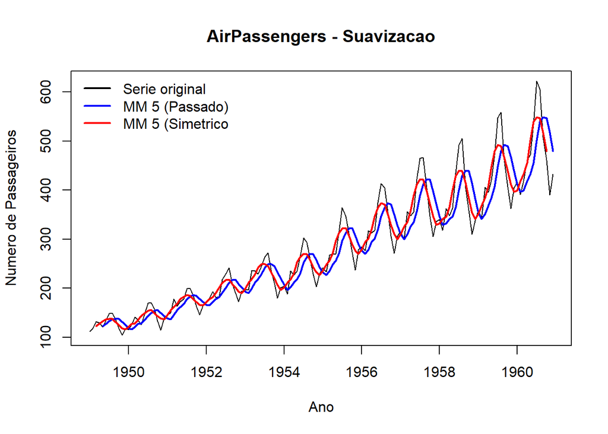

```r
# Gráfico
plot(X, main="AirPassengers - Suavizacao", ylab="Numero de Passageiros", xlab="Ano")

# Adiciona suavizações
lines(pass5, col="blue", lwd=2)
lines(sim5, col="red", lwd=2)

# Legenda
legend("topleft",
       legend=c("Serie original","MM 5 (Passado)","MM 5 (Simetrico"),
       col=c("black","blue","red"),
       lty=1, lwd=2, bty="n")
```

### Decomposicao Aditiva Clássica (Manual)

Agora que entendemos como extrair a tendencia, podemos partir para decompor a serie como um todo, nesse caso vamos extrair a tendencia e encontrar a sazonalidade e depois os residuos.

#### Extraindo a Tendencia

Inicialmente vamnos usar as MM para obter a componente de tendencia. E em seguida vamos subtrair da serie original para obter uma serie sem tendencia.

```r
X = AirPassengers
T = filter(X,rep(1/13,13,sides=2))
Z = X - T
```

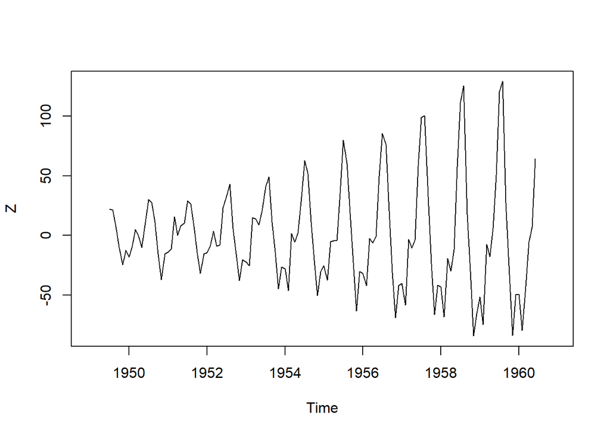

```r
plot(Z)
```

#### Extraindo a Sazonalidade

Agora vamos criar uma matriz com 12 colunas (uma para cada mes) em seguida vamos distribuir as observacoes e tirar a media, assim obtemos as medias mensais da nossa serie e com isso pode usar para estimar a sazonalidade.

```r
n_periodos <- length(X) / 12

MS <- matrix(Z, byrow = TRUE, ncol = 12)

S <- colMeans(MS, na.rm = TRUE)

S <- ts(rep(S, n_periodos), start = start(X), frequency = frequency(X))
```

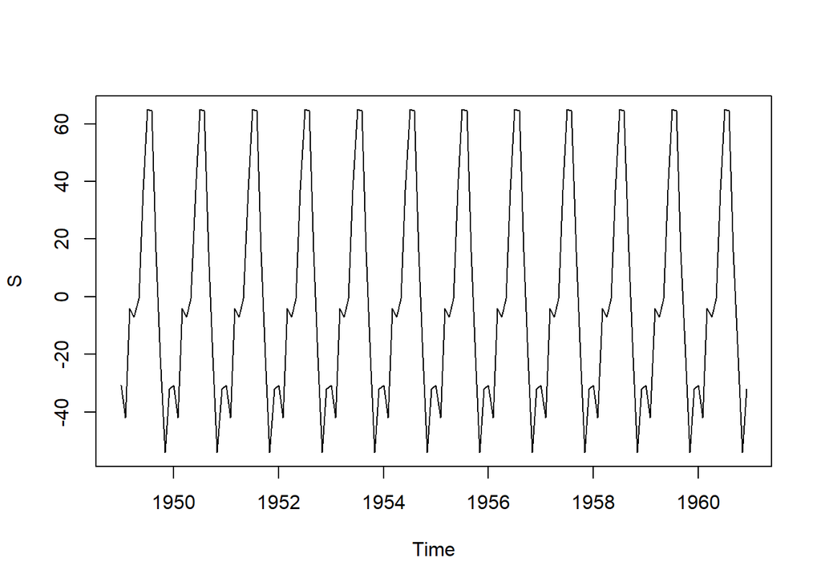

```r
plot(S)
```

#### Residuos

Agora que temos os termos de tendencia e sazonalide podemos subtrair deles da serie original para obter o residuo.

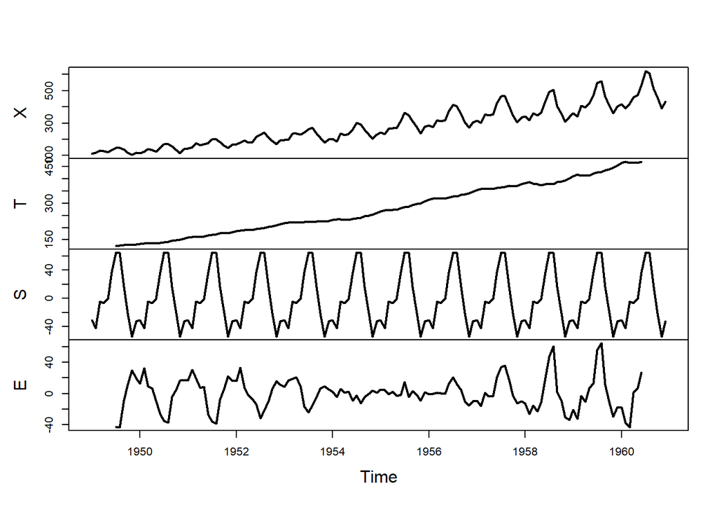

```r
E <- X - T - S

plot(cbind(X, T, S, E), main = "", plot.type = "m", lwd = 2)
```

### Decomposicao Multiplicativa Clássica (Manual) (Exercicio 1)

#### Obtendo a Tendencia

Aqui repetimos o que fizemos na aditiva onde pegamos a tendencia pela MM porem por ser multiplicativa para obter a serie com tendencia ajustada temos que dividir a serie original.

```r
X = AirPassengers
T = filter(X,rep(1/13,13,sides=2))
Z = X/T
```

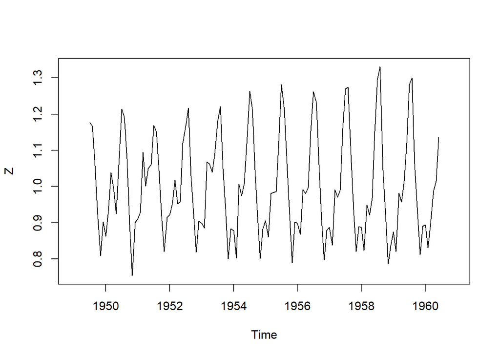

```r
plot(Z)
```

### Obtendo a Sazonalidade

```r
n_periodos <- length(X) / 12

MS <- matrix(Z, byrow = TRUE, ncol = 12)

S <- colMeans(MS, na.rm = TRUE)

S <- ts(rep(S, n_periodos), start = start(X), frequency = frequency(X))
```

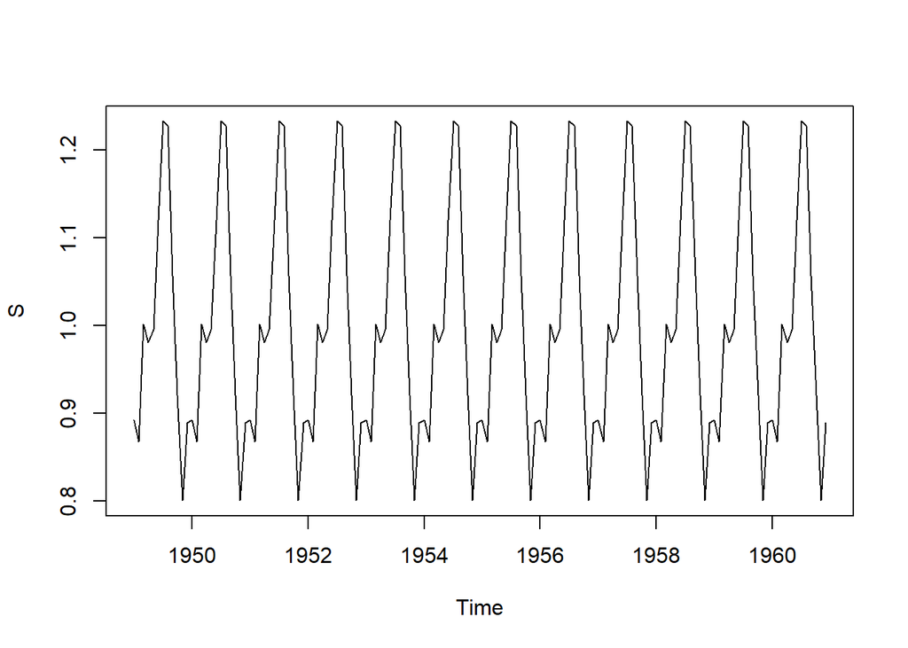

```r
plot(S)
```

### Residuos

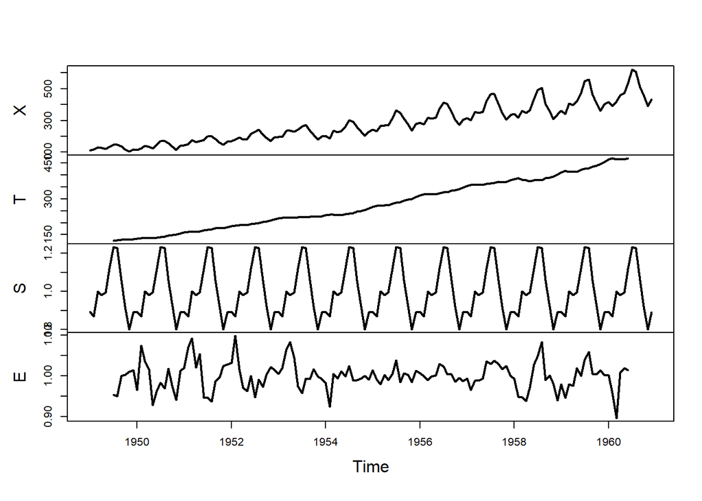

```r
E <- X/(T*S)

plot(cbind(X, T, S, E), main = "", plot.type = "m", lwd = 2)
```

### Ajustando a decomposicao Aditiva e Multiplicativa (Exercicio 2)

Aqui vamos decompor outras series disponiveis no R

```r
data("UKgas")
data("USAccDeaths")
data("co2")
data("nottem")
data("presidents")
```

#### UKgas

- O que é: consumo trimestral de gás no Reino Unido.
- Período aproximado: 1960–1986.
- Frequência: 4 (trimestres).
- O que observar: tendência de longo prazo (expansão do consumo ao longo dos anos) e sazonalidade trimestral bem marcada (invernos vs. verões).

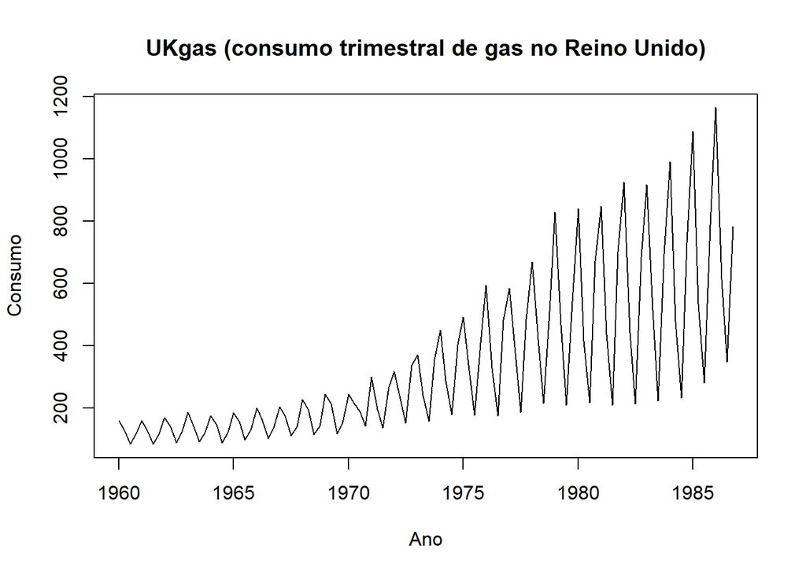

```r
plot(UKgas, main = "UKgas (consumo trimestral de gas no Reino Unido)", ylab = "Consumo", xlab = "Ano")
```

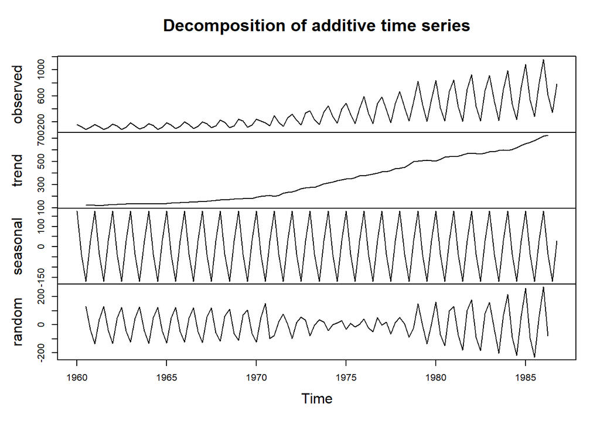

```r
plot(decompose(UKgas,type = "a"))
```

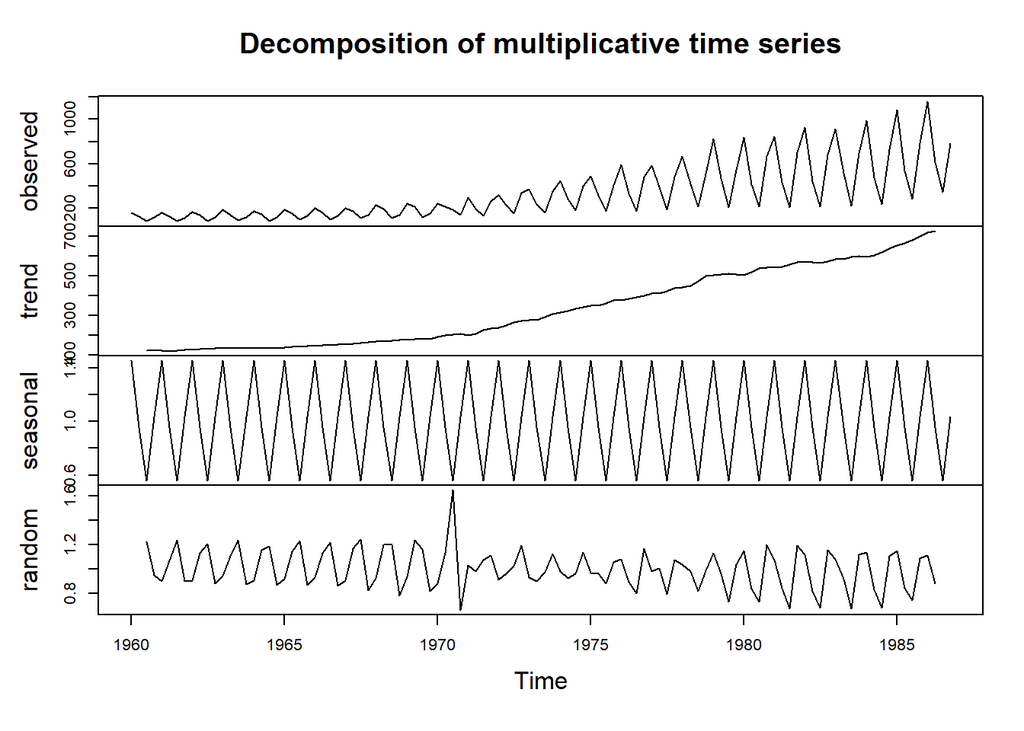

```r
plot(decompose(UKgas,type = "m"))
```

#### USAccDeaths

- O que é: número de mortes mensais por acidentes automobilísticos nos EUA.
- Período aproximado: 1973–1978.
- Frequência: 12 (mensal).
- O que observar: sazonalidade anual (picos nos meses mais movimentados/condições sazonais) e alguma variação de nível ao longo dos anos.

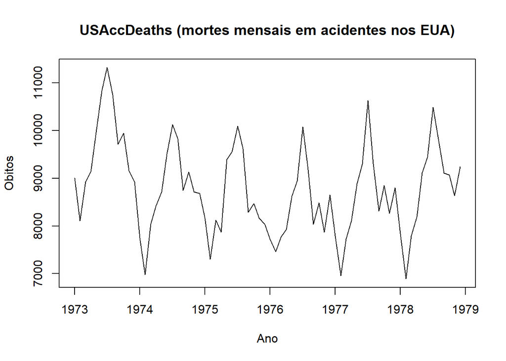

```r
plot(USAccDeaths, main = "USAccDeaths (mortes mensais em acidentes nos EUA)", ylab = "Obitos", xlab = "Ano")
```

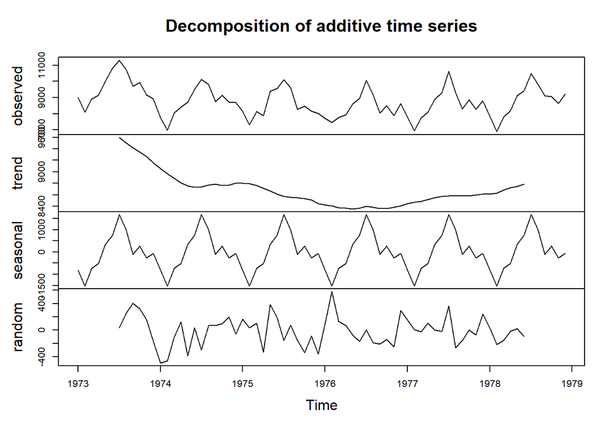

```r
plot(decompose(USAccDeaths,type = "a"))
```

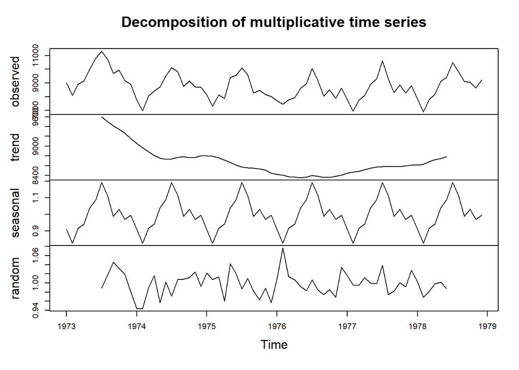

```r
plot(decompose(USAccDeaths,type = "m"))
```